# From @JoeBiden to @POTUS

組員：簡郁展, 潘立恆, 邱繼賢, 劉慧新, 陳暘

2021/6/8

# 1 Problematic

1. 拜登正式就任美國第46任總統後，Twitter也將總統官方帳號POTUS轉交拜登團隊。多數美國媒體聲稱過去`@JoeBiden`的經營主要面向美國大眾推廣政策理念，相反的川普帳號只跟自己的支持者對話。而時下未見有拜登`@POTUS`的詳細分析，我們有興趣的是拜登`@POTUS`在公共關係經營上還是走傳統、規律路線嗎？拜登`@POTUS`是僅僅將twitter當作一個宣傳政令跟政府講話的媒體平台，還是存在明顯的情緒宣傳？
2. 本專案預設即使去掉停詞之後，取得的關鍵字對於推文含意的辨識度還是有權重差異的。有些特別具象化單詞會能夠指涉與特定政策意涵或與特定政策事件相關，例如`vaccine/covid/jobs/economy/plan`等等。而其他較模糊的政治相關用語(例如`president/senate/congress`等)、一般單詞則被視為不具有明確政策資訊內涵。
3. 因此，本專案簡單假設如果`@POTUS`只是單純宣傳政令或講話的帳號，應該大量含有上述辨識度高的具象化單字以指涉特定議題或事件。或者，在喜歡數或轉推數較高的推文中，要可以觀察到上述情形。同時，本文也會比較`@JoeBiden`在情緒分析是否與`@POTUS`有明顯不同。

# 2 General Analysis

## 2.1 Preprocessing

首先，從`Twitter API`與`twitteR()`獲得的推文擷取資料載入，資料包含拜登`@POTUS`帳號截止至2021年6月13日共760筆的資料。再來剔除不必要的欄位，並進行發推來源的提取與時區調整。

```r
library(dplyr)
library(tibble)
library(ggplot2)
library(stringr)
library(tidyr)
library(lubridate)
library(scales)
library(tidytext)
library(textdata)
library(cowplot)
#Load the dataset obtained from TwitteR package
load(file = "biden_tweets_df.rda")
load(file = "AllJoeBidenTweets.rda")
# Mutate source column and select other meaningful columns
df <- biden_tweets_df %>%
    mutate(source = sapply(biden_tweets_df$statusSource , function(x) {
        if (str_detect(x, pattern = "Twitter Web App")) return("Twitter_Web_App")
        else if (str_detect(x, pattern = "Periscope")) return("Periscope")
        else if (str_detect(x, pattern = "Twitter Media Studio")) return("Twitter_Media_Studio")
        else if (str_detect(x, pattern = "Sprinklr")) return("Sprinklr")
        else return("The_White_House")
    })) %>%
    select(id, source, text, created, retweetCount, favoriteCount) %>%
    mutate(hour = hour(with_tz(created, "EST")))
```

## 2.2 Collect tweet words

使用`unnest_tokens()`從推文內容中提取出單詞並去掉停詞。

```r
reg <- "([^A-Za-z\\d#@']|'(?![A-Za-z\\d#@]))"
tweet_words <- df %>%
    filter(!str_detect(text, '^"')) %>%
    mutate(text = str_replace_all(text, "https://t.co/[A-Za-z\\d]+|&amp;", "")) %>%
    unnest_tokens(word, text, token = "regex", pattern = reg) %>%
    filter(!word %in% stop_words$word,
           str_detect(word, "[a-z]")) %>%
    arrange(desc(favoriteCount))
```

## 2.3 Time line

對`@POTUS`從2月到六月的發文狀況做總覽，觀察不同發文來源在`favoriteCount 以及 retweetCount`的表現。

### 2.3.1 Time line of retweetCount and FavoriteCount from Feb to June

下面兩張圖可以明顯看出大部分推文都是從`The White House` 發出來的，而`favoriteCount`的數量級大致上為`retweetCount`的十倍，兩者趨勢大體上相同。

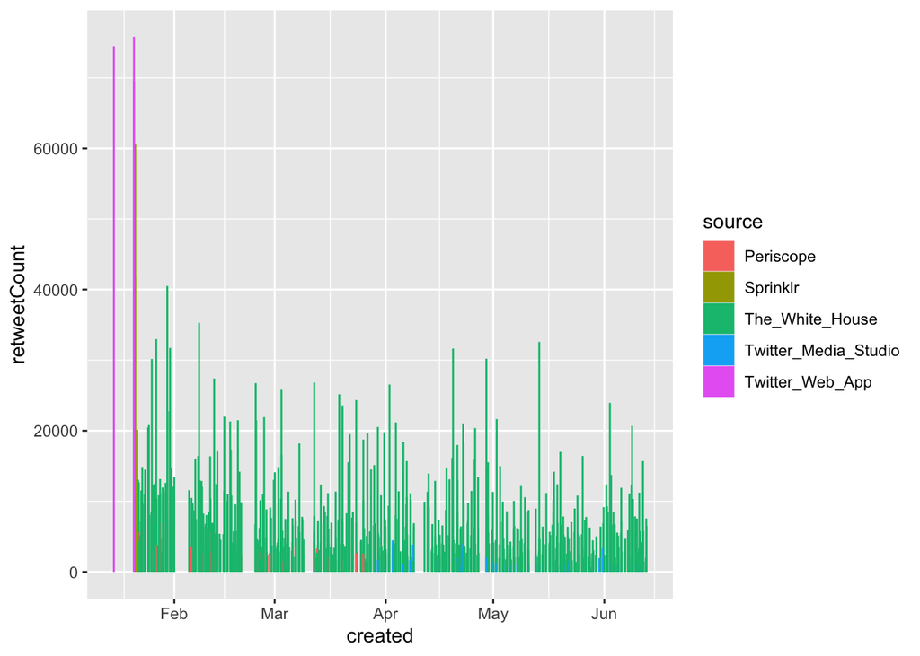

```r
ggplot(data = df) +
    geom_col(mapping = aes(x = created, y = retweetCount, color = source, fill = source))
```

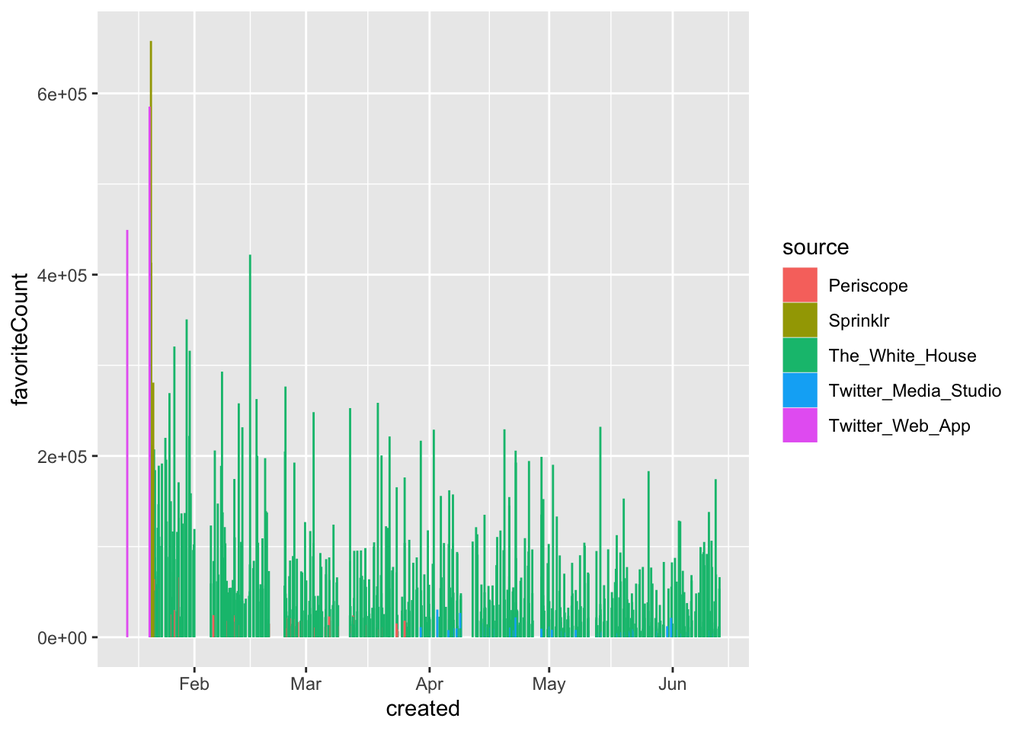

```r
ggplot(data = df) +
    geom_col(mapping = aes(x = created, y = favoriteCount, color = source, fill = source))
```

### 2.3.2 Tweeting in Hour of a Day

將發文時間轉換成美東時間後，可以觀察到以下現象：

- `@POTUS`發文在下午較頻繁，並在下午1點、晚上8點左右達到高峰，而且凌晨1-5點的時間段發文比例相當低，發文時間相當規律。
- 將每個時間段累積喜歡數加總後，發現與發文比例的趨勢相似，但發文數量多也可能造成喜歡數加總較多的現象。
- 若檢視每個時間段的喜歡數平均，在下午12-1點、下午5-6點、晚上8-10點都有明顯上升的趨勢，但與前兩張圖不同的是最高峰並非發生在晚上8點。除了晚上8點後發文比例比較少外，晚上8點後轉推數明顯較高也可能是提高觸及率與喜歡數的主要原 因。此外，若內文包含重要議題或是受關注的社會事件，也可能獲得可觀的喜歡與轉推。

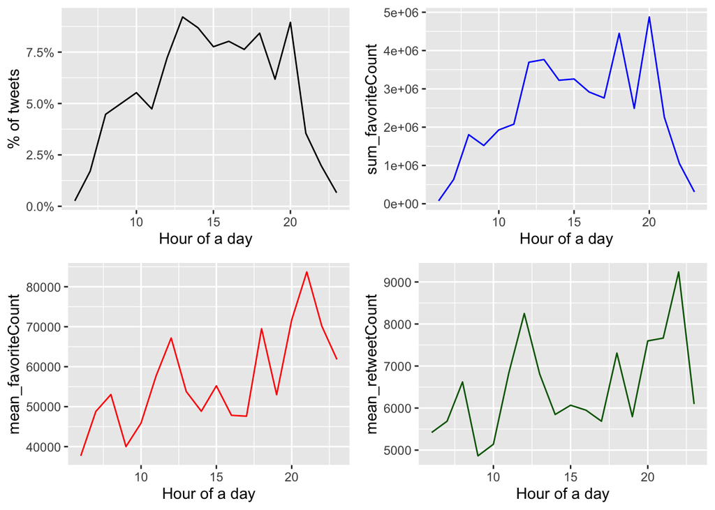

```r
tweeting_hour <- df %>%
    group_by(hour) %>%
    summarise(number=n(),
              sum_favoriteCount = sum(favoriteCount),
              sum_retweetCount = sum(retweetCount),
              mean_favoriteCount = mean(favoriteCount),
              mean_retweetCount = mean(retweetCount)) %>%
    arrange(desc(number))

p1 <- df %>%
    count(hour = hour(with_tz(created, "EST"))) %>%
    mutate(percent = n / sum(n)) %>%
    ggplot(mapping = aes(hour, percent)) +
    geom_line() +
    scale_y_continuous(labels = percent_format()) +
    labs(x = "Hour of a day", y = "% of tweets")
p2 <- ggplot(tweeting_hour) +
    geom_line(aes(hour, sum_favoriteCount), color = "blue") +
    labs(x = "Hour of a day")
p3 <- ggplot(tweeting_hour) +
    geom_line(aes(hour, mean_favoriteCount), color = "red") +
    labs(x = "Hour of a day")

p4 <- ggplot(tweeting_hour) +
    geom_line(aes(hour, mean_retweetCount), color = "darkgreen") +
    labs(x = "Hour of a day")

plot_grid(p1, p2, p3, p4, ncol = 2)
```

## 2.4 Picture/Link from each source

`@POTUS`的推文幾乎都附有照片或連結，差距非常顯著。藉由直接觀察拜登的推文，以及推文附帶的文字敘述進而推論這些圖片或連結多與特定會議、政策或社會事件有關。(詳參`Comparison of Words`)

```r
# Whether a Picture/Link is likely to be included in a Tweet
picture <- df %>%
    filter(!str_detect(text, '^"')) %>%
    count(source, picture = ifelse(str_detect(text, "t.co"),
                                   "Picture/link", "No picture/link"))
picture
```

```
## # A tibble: 7 x 3
##   source               picture             n
##   <chr>                <chr>           <int>
## 1 Periscope            Picture/link       30
## 2 Sprinklr             No picture/link     1
## 3 Sprinklr             Picture/link        4
## 4 The_White_House      No picture/link    49
## 5 The_White_House      Picture/link      628
## 6 Twitter_Media_Studio Picture/link       45
## 7 Twitter_Web_App      Picture/link        3
```

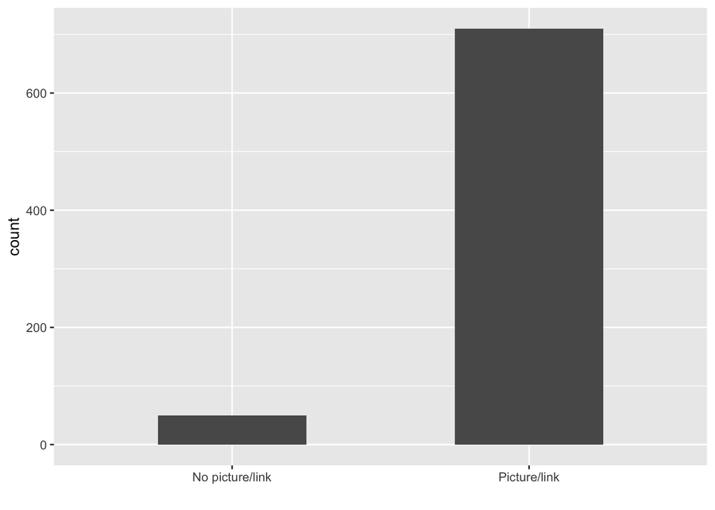

```r
df %>%
    filter(!str_detect(text, '^"')) %>%
    count(picture = ifelse(str_detect(text, "t.co"),
                                   "Picture/link", "No picture/link")) %>%
    ggplot() +
    geom_bar(aes(picture, n), stat = "identity", width = 0.5) +
    labs(x = "", y = "count")
```

# 3 Comparison of Words

在文字分析的環節，我們希望可以知道: - `@POTUS`最常提到的詞彙，以及這些詞彙是否是`Problematic的假設`中在政策意涵上具有辨識度的字詞。 - 區分這些詞彙的來源傾向。

## 3.1 Word Frequency Plot

首先是詞頻圖，可以發現`@POTUS`整體而言政策辨識度高的詞彙包含: `plan/jobs/covid/tune/rescue/vaccinated`。推測與拜登的紓困法案《The American Jobs Plan》、《The American Rescue Plan Act of 2021》以及疫苗施打有關。

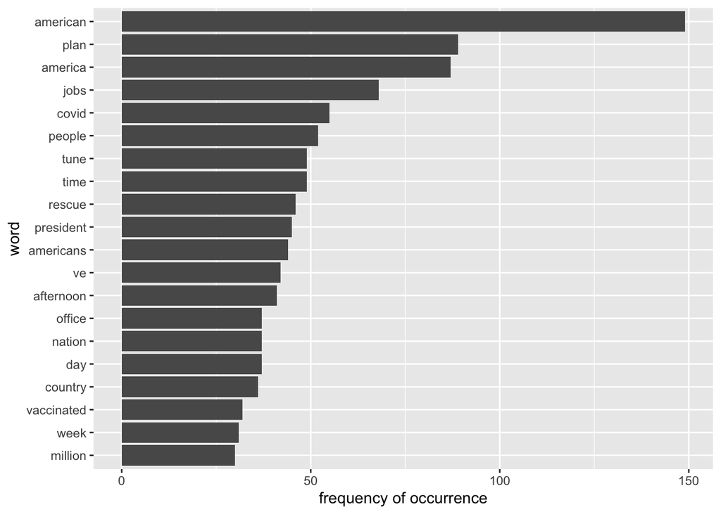

```r
tweet_words %>%
    count(word) %>%
    mutate(word = reorder(word, n)) %>%
    top_n(20, n) %>%
    ggplot() +
    geom_bar(aes(x = word, y = n), stat = "identity") +
    ylab("frequency of occurrence") +
    coord_flip()
```

## 3.2 Word Weighting of different sources (Video Streaming App and The White House)

接著我們希望了解`@POTUS`推文內容的來源傾向，尤其是使用影音串流平台(`Periscope`)以及一般發文管道`The White House`在文字使用傾向上區別。因此，可以透過計算勝算比(odds ratio)來知道相對於影音平台，`The White House`更傾向提及那些文字內容，反之亦然。

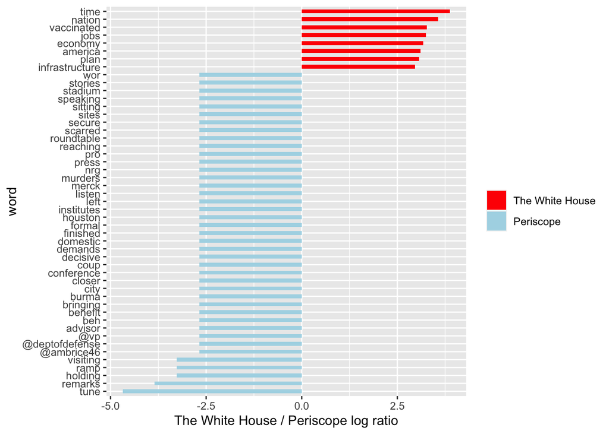

```r
# Word Weighting of different sources (Video Streaming App and The White House)
WhiteHouse_periscope_ratios <- tweet_words %>%
  count(word, source) %>%
  filter(sum(n) >= 5) %>%
  spread(source, n, fill = 0) %>%
  ungroup() %>%
  mutate_each(funs((. + 1) / sum(. + 1)), -word) %>%
  mutate(logratio = log2(The_White_House / Periscope)) %>%
  arrange(desc(logratio))

WhiteHouse_periscope_ratios %>%
  group_by(logratio > 0) %>%
  top_n(8, abs(logratio)) %>%
  ungroup() %>%
  mutate(word = reorder(word, logratio)) %>%
  ggplot(aes(word, logratio, fill = logratio < 0)) +
  geom_bar(stat = "identity", width = 0.5) +
  coord_fixed(ratio = 1000000) +
  coord_flip() +
  ylab("The White House / Periscope log ratio") +
  scale_fill_manual(name = "", labels = c("The White House", "Periscope"),
                    values = c("red", "lightblue"))
```

可以發現`@POTUS`對於推文內容具有系統性的管理:

- 從影音平台發布的推文多與舉辦會議或是記者會有關，包含`tune/remarks/holding/visiting`；而且較`The White House`更傾向標註其他政府的 twitter 帳號，包含副總統(`@vp`)、國防部(`@deptofdefense`)、白宮國內政策委員會總監(`@ambrice46`)。
- `The White House`則較傾向單純發布政策內容相關的字詞，例如`vaccinated/jobs/economy/plan/infrastructure`，並且具有相較`Periscope`而言更高的文字辨識度(log ratio的值比較有次序)。

# 4 Sentiment Analysis

最後情緒分析的環節，我們想要知道`@POTUS`的文字使用在情緒上表現，包含較常傳達哪些情緒、以及不同類別的情緒傳達分別由哪字詞組成。對此，我們採用`library(textdata)`中的`get_sentiments()`獲取`NRC Word-Emotion Association lexicon`，將`POTUS`使用的英文單詞分成十種情緒類別，比較`@POTUS`跟`@JoeBiden`的差異。

## 4.1 Tweets Sentiment Overview

`@POTUS`整體較常使用正面的情緒字眼，包含`positive/trust`，以及中性的`anticipation`。

```r
sentiment_overview <- tweet_words %>%
    inner_join(get_sentiments("nrc")) %>%
    filter(!is.na(sentiment)) %>%
    count(sentiment, sort = TRUE)

sentiment_overview
```

```
## # A tibble: 10 x 2
##    sentiment        n
##    <chr>        <int>
##  1 positive       863
##  2 trust          591
##  3 anticipation   447
##  4 negative       386
##  5 joy            285
##  6 fear           224
##  7 sadness        172
##  8 anger          168
##  9 surprise       149
## 10 disgust         74
```

## 4.2 Tweets Sentiment by Source

`@POTUS`每種發文來源的情緒傾向都類似。

```r
sources <- tweet_words %>%
    group_by(source) %>%
    mutate(total_words = n()) %>%
    ungroup() %>%
    distinct(id, source, total_words)

by_source_sentiment <- tweet_words %>%
    inner_join(get_sentiments("nrc"), by = "word") %>%
    count(sentiment, id) %>%
    ungroup() %>%
    complete(sentiment, id, fill = list(n = 0)) %>%
    inner_join(sources) %>%
    group_by(source, sentiment, total_words) %>%
    summarize(words = sum(n)) %>%
    arrange(desc(total_words)) %>%
    ungroup()

by_source_sentiment
```

```
## # A tibble: 50 x 4
##    source          sentiment    total_words words
##    <chr>           <chr>              <int> <dbl>
##  1 The_White_House anger               5210   156
##  2 The_White_House anticipation        5210   414
##  3 The_White_House disgust             5210    67
##  4 The_White_House fear                5210   207
##  5 The_White_House joy                 5210   267
##  6 The_White_House negative            5210   360
##  7 The_White_House positive            5210   780
##  8 The_White_House sadness             5210   162
##  9 The_White_House surprise            5210   138
## 10 The_White_House trust               5210   544
## # ... with 40 more rows
```

## 4.3 Usage of Common Sentimental Words

綜合各情緒類別的字詞組成，可以發現出現頻率較高且具備政策意涵的詞彙有:

- `positive/trust`: `rescue/vaccine/economy`
- `anticipation`: `plan`
- `negative/fear/sadness/anger`: `pandemic/tax`

其他大部分的詞彙則無法分辨是否具備特別意義。

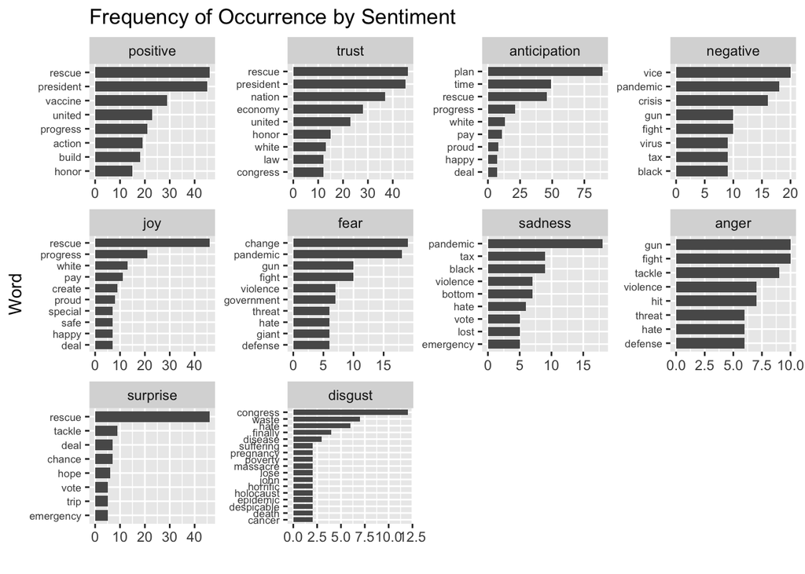

```r
nrc_word_counts <- tweet_words %>%
  inner_join(get_sentiments("nrc")) %>%
  count(word, sentiment, sort = TRUE) %>%
  ungroup()

nrc_word_counts$sentiment =
  factor(nrc_word_counts$sentiment, levels = sentiment_overview$sentiment)

nrc_word_counts %>%
  group_by(sentiment) %>%
  top_n(8, n) %>%
  arrange(desc(n)) %>%
  ungroup() %>%
  ggplot() +
  geom_histogram(aes(x = reorder(word, n), y = n), stat = "identity", width = 0.75) +
  coord_flip() +
  facet_wrap(~sentiment, scales = "free") +
  theme(axis.text.y = element_text(size = rel(0.75))) +
  labs(x = "Word", y = "", title = "Frequency of Occurrence by Sentiment")
```

## 4.4 Usage of Common Sentimental Words with Top Fifty FavoriteCount

```r
# Preprocessing
favorite <- df %>%
  arrange(desc(favoriteCount)) %>%
  top_n(50)

# Collecting Tweets Words
reg <- "([^A-Za-z\\d#@']|'(?![A-Za-z\\d#@]))"
favorite_words <- favorite %>%
    filter(!str_detect(text, '^"')) %>%
    mutate(text = str_replace_all(text, "https://t.co/[A-Za-z\\d]+|&amp;", "")) %>%
    unnest_tokens(word, text, token = "regex", pattern = reg) %>%
    filter(!word %in% stop_words$word,
           str_detect(word, "[a-z]")) %>%
    arrange(desc(favoriteCount))

# View the difference between whole @POTUS tweets and its top 50 favorite tweets
sentiment_overview_50 <- favorite_words %>%
    inner_join(get_sentiments("nrc")) %>%
    filter(!is.na(sentiment)) %>%
    count(sentiment, sort = TRUE)

sentiment_overview_50
```

```
## # A tibble: 10 x 2
##    sentiment        n
##    <chr>        <int>
##  1 positive       117
##  2 trust          104
##  3 anticipation    73
##  4 negative        59
##  5 joy             45
##  6 fear            25
##  7 surprise        24
##  8 anger           23
##  9 sadness         22
## 10 disgust          6
```

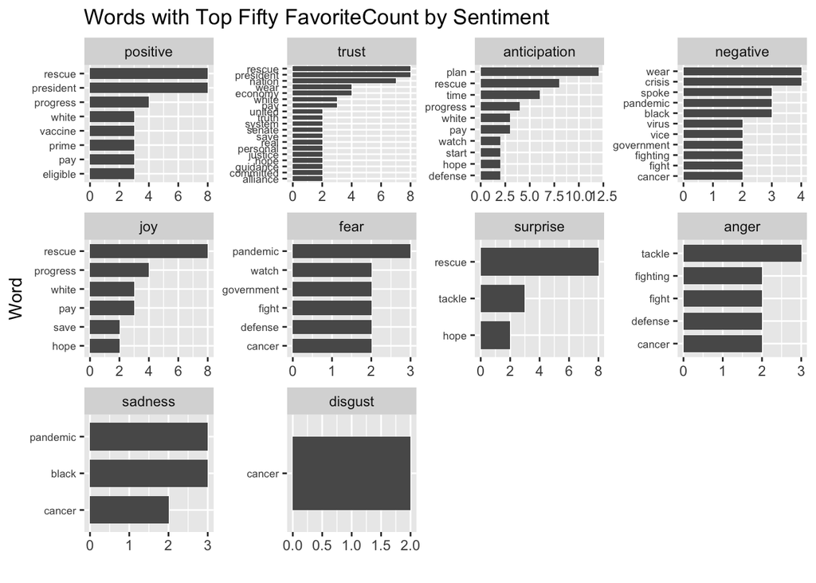

```r
favorite_word_counts <- favorite_words %>%
  inner_join(get_sentiments("nrc")) %>%
  count(word, sentiment, sort = TRUE) %>%
  ungroup()

favorite_word_counts$sentiment =
  factor(favorite_word_counts$sentiment, levels = sentiment_overview_50$sentiment)


favorite_word_counts$sentiment =
  factor(favorite_word_counts$sentiment, levels = sentiment_overview_50$sentiment)

favorite_word_counts %>%
  filter(n > 1) %>%
  group_by(sentiment) %>%
  top_n(8, n) %>%
  ggplot() +
  geom_histogram(aes(x = reorder(word, n), y = n), stat = "identity", width = 0.75) +
  coord_flip() +
  facet_wrap(vars(sentiment), scales = "free") +
  theme(axis.text.y = element_text(size = rel(0.75))) +
  labs(x = "Word", y = "", title = "Words with Top Fifty FavoriteCount by Sentiment")
```

## 4.5 Compared with @JoeBiden

`@JoeBiden`截至2020年11月使用`positive`與`negative`類別詞彙的傾向不相上下，而且兩者的使用量皆遠多過其他情緒類別。`trust/fear/anger/sadness`等情緒類別則差距不大。 這代表`@JoeBiden`在情緒傳達上的複雜程度遠大於`@POTUS`。`@POTUS`只傾向傳達正面情緒，但`@JoeBiden`都會使用。

```r
reg <- "([^A-Za-z\\d#@']|'(?![A-Za-z\\d#@]))"
tweet_words2 <- AllJoeBidenTweets %>%
    filter(!str_detect(tweet, '^"')) %>%
    mutate(text = str_replace_all(tweet, "https://t.co/[A-Za-z\\d]+|&amp;", "")) %>%
    unnest_tokens(word, text, token = "regex", pattern = reg) %>%
    filter(!word %in% stop_words$word,
           str_detect(word, "[a-z]")) %>%
    arrange(desc(likes))

sentiment_counts <- tweet_words2 %>%
  left_join(get_sentiments("nrc")) %>%
  count(word, sentiment, sort = TRUE) %>%
  ungroup()

sentiment_df <-  sentiment_counts %>%
  group_by(sentiment) %>%
  summarise(n = n()) %>%
  arrange(desc(n)) %>%
  ungroup()

sentiment_df
```

```
## # A tibble: 11 x 2
##    sentiment        n
##    <chr>        <int>
##  1 <NA>          7685
##  2 positive       789
##  3 negative       707
##  4 trust          475
##  5 fear           401
##  6 anger          352
##  7 sadness        336
##  8 anticipation   305
##  9 joy            260
## 10 disgust        220
## 11 surprise       171
```

即使資料擷取時間有涵蓋總統選舉期間，`@JoeBiden`除了選舉詞彙與人物詞彙之外(例如`president/vote/trump`)還是多使用模糊字眼。可以推論相較`@POTUS`，`@JoeBiden`更加的情緒化，而不傾向呈現具體政策意涵或社會事件。

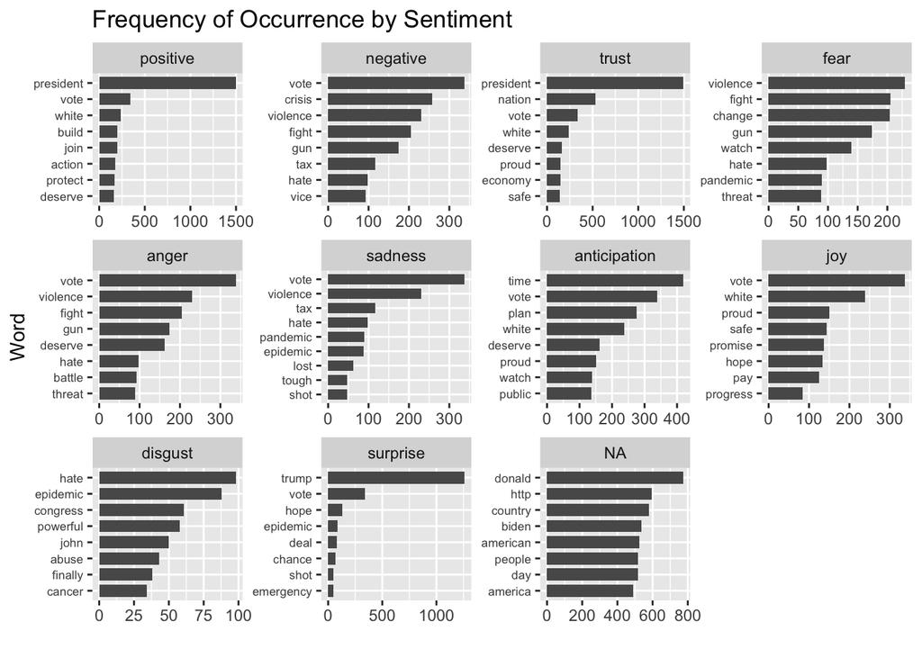

```r
sentiment_counts$sentiment =
  factor(sentiment_counts$sentiment, levels = sentiment_df$sentiment)

sentiment_counts %>%
  group_by(sentiment) %>%
  top_n(8, n) %>%
  arrange(desc(n)) %>%
  ungroup() %>%
  ggplot() +
  geom_histogram(aes(x = reorder(word, n), y = n), stat = "identity", width = 0.75) +
  coord_flip() +
  facet_wrap(vars(sentiment), scales = "free") +
  theme(axis.text.y = element_text(size = rel(0.75))) +
  labs(x = "Word", y = "", title = "Frequency of Occurrence by Sentiment")
```